# Assault Incidence in Seattle Not Impacted by Weather

James Lamb

## Introduction

For this short report, I sought to explore the relationship between weather and assaults using crime data recorded in the city of Seattle, WA in the Summer of 2014.

The crime data come from the city of Seattle’s [open data portal](https://data.seattle.gov/). The specific subset of the data used in this assignment was provided by the professor and is available [here](https://raw.githubusercontent.com/uwescience/datasci_course_materials/master/assignment6/seattle_incidents_summer_2014.csv). Weather data used below were pulled from [Weather Underground](http://www.wunderground.com/) using the [weatherData](https://cran.r-project.org/web/packages/weatherData/index.html) package in R.

**Note**- The raw R Markdown behind this post can be found at [this GitHub repo](https://github.com/jameslamb/MOOC_Stuff/blob/master/Communicating_Data_Science_Results/Assignments/UWCOMM_Assignment1.rmd).

## Exploratory Analysis

More specifically, I set out to create some simple visualizations showing the relationship between key weather variables and the incidence of assaults.

Figure 1 below shows the frequency and composition of assaults by weather conditions in the hour that the assault took place. It’s obvious from this chart that non-aggravated assaults are far more likely to occur than aggravated assaults (thankfully!), but beyond that there is little evidence that weather conditions contribute strongly to the prevalence of assaults. Notice that “Clear” was the second most prevalent condition at the time of assaults. In a dataset this messy, I’m not comfortable saying that the difference between the frequency of assaults in “Clear” and “Mostly Cloudy” conditions is meaningful.

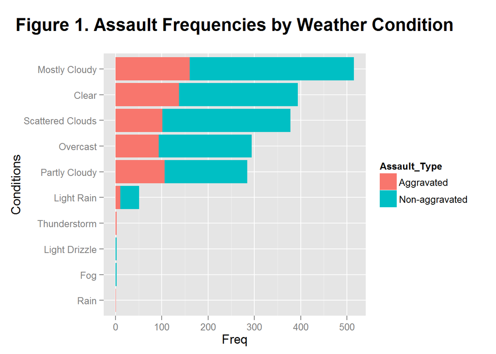

## Conclusion

This short analysis suggests no strong relationship between weather conditions and assault incidence in the 2014 Seattle crime data. Much more work would need to be strengthen the claim, but this initial inquiry suggests that researchers hoping to model crime should start with non-weather factors.